# Prática Estatística II

Alimentação de prematuros: comparação entre  
técnica sonda-dedo e seringa de 20 mL

Davi Lucas (daviij@id.uff.br)  
Marcos Paulo (mp_dias@id.uff.br)

Universidade Federal Fluminense

20/09/2026

# Introdução

Como os métodos de oferta se relacionam com o derramamento de leite e os sinais vitais?

## O artigo e a pergunta de pesquisa

**Volume derramado, saturação de oxigênio e frequência cardíaca durante a alimentação de recém-nascidos prematuros: comparação entre dois métodos alternativos de oferta**

**Autoras:** Viviane Castro de Araújo, Ana Caroline Martinez Maciel, Mariana de Almeida Ribeiro Paiva e Ana Cristina Barreto Bezerra.

**Motivação:** seringa e técnica sonda-dedo eram usadas na rotina neonatal, mas faltavam evidências sobre a perda de leite e a resposta dos sinais vitais.

**Objetivo:** comparar seringa e **TSD (técnica sonda-dedo)** quanto à dieta oferecida e derramada, à saturação de oxigênio e à frequência cardíaca.

## Motivação e métodos de oferta

### Por que investigar?

Prematuros podem apresentar dificuldades na alimentação oral, especialmente durante a transição da sonda para a via oral.

A seringa e a técnica sonda-dedo (TSD) são utilizadas como alternativas de alimentação, mas havia pouca evidência sobre seus resultados.

- quantidade de dieta oferecida;
- quantidade de dieta derramada;
- saturação de oxigênio;
- frequência cardíaca.

### O que foi comparado?

**Seringa de 20 mL:** oferta dirigida à face interna da bochecha.

**TSD (técnica sonda-dedo):** sonda fixada ao dedo mínimo do avaliador, conectada a uma seringa. A oferta acompanha a sucção.

# Metodologia estatística

O desenho do estudo determina a escolha do teste.

## Amostra e critérios de inclusão

### Amostra

**30 prematuros** - 13 meninas - 17 meninos - Unidade neonatal de Porto Velho

**18 AIG** — peso adequado para a idade gestacional

**12 PIG** — peso pequeno para a idade gestacional

### Seleção

Foram incluídos bebês:

- com idade corrigida **≥ 34 semanas**;
- recebendo alimentação oral há pelo menos **2 dias**;
- em estado de alerta e clinicamente estáveis.

Também foram excluídas algumas condições clínicas que poderiam interferir na alimentação.

**Estudo quase-experimental:** os pesquisadores aplicaram os dois métodos aos mesmos bebês. Cada bebê foi seu próprio controle.

**Ordem:** seringa → TSD.

## Variáveis e comparações

| Papel | Variáveis | Comparação |
| --- | --- | --- |
| Fator principal | Método de oferta: TSD e seringa | Duas condições no mesmo bebê |
| Desfechos alimentares | Volumes oferecido e derramado (%), volume em 5 min (%), volume/tempo (mL/min) e tempo (min) | Teste t pareado |
| Desfechos fisiológicos | Saturação de oxigênio (%) e frequência cardíaca (bpm) | Antes, durante e depois, em cada método |
| Subgrupos | AIG (18) e PIG (12) | Comparação entre grupos distintos |

## Teste t pareado: a diferença em cada bebê

**30 bebês → 30 diferenças:** $D_i = Y_{i,\text{seringa}} - Y_{i,\text{TSD}}$

### O que foi testado?

$H_0: \mu_D = 0$ — sem diferença média.

$H_1: \mu_D \ne 0$ — existe diferença média.

$$t = \frac{\bar D}{s_D / \sqrt{30}}$$

**29 graus de liberdade · α = 0,05**

### Quando o teste é adequado?

- Medidas pareadas no mesmo bebê.
- Independência entre os bebês.
- Diferenças aproximadamente normais, com atenção a valores extremos.

$\bar D$: média das diferenças. $s_D$: desvio padrão das diferenças.

**Normalidade no artigo:** os autores afirmam que os resultados apresentaram distribuição normal, mas não descrevem como essa condição foi verificada. O artigo não informa teste de normalidade, p-valor ou gráfico de diagnóstico.

## ANOVA e Tukey: duas aplicações no artigo

### AIG versus PIG

**Dois grupos distintos**, comparados em cada método.

$$H_0: \mu_{AIG} = \mu_{PIG}$$

A Tabela 2 identifica o teste como **ANOVA**.

Com dois grupos, a ANOVA clássica equivale ao teste t para grupos independentes com variância comum: **$F = t^2$**.

### Antes, durante e depois

**Três momentos nos mesmos bebês**, em cada método.

$$H_0: \mu_{antes} = \mu_{durante} = \mu_{depois}$$

**ANOVA:** avalia se existe diferença entre os momentos.

**Tukey:** identifica quais pares de momentos diferem.

**Atenção às medidas repetidas:** o artigo não esclarece se a ANOVA considerou a dependência entre os momentos. Uma ANOVA de grupos independentes não corresponde a esse desenho.

## Cada teste responde a uma pergunta diferente

| Teste usado | Estrutura dos dados | Pergunta que ele responde |
| --- | --- | --- |
| **Teste t pareado** | 30 diferenças, um par por bebê | O método de oferta (TSD vs. seringa) muda a média de uma variável, **no mesmo bebê**? |
| **ANOVA (grupos)** | AIG e PIG são grupos diferentes | Bebês AIG e PIG **diferem entre si**, dentro de um mesmo método? |
| **ANOVA (momentos) + Tukey** | Antes/durante/depois, no mesmo bebê, em cada método | A variável muda **ao longo do tempo** dentro do mesmo método? Se muda, **entre quais momentos**? |

Antes de olhar qualquer p-valor, a pergunta certa já indica o teste certo: comparar o mesmo bebê em duas condições pede teste pareado; comparar grupos diferentes pede ANOVA entre grupos; comparar vários momentos no mesmo bebê pede ANOVA de medidas repetidas (com Tukey para localizar a diferença).

# Resultados

Resultados publicados, com interpretação das comparações.

## Comparação dos métodos: Tabela principal

| Variável | TSD | Seringa | Valor de p |
| --- | --- | --- | --- |
| Volume oferecido (%) | 78,9 ± 21,9 | 88,8 ± 13,3 | 0,029 |
| Volume oferecido em 5 min (%) | 37,6 ± 11,2 | 39,3 ± 8,8 | 0,400 |
| Volume derramado (%) | 2,3 ± 4,8 | 17,2 ± 7,3 | < 0,001 |
| Relacao volume/tempo (mL/min) | 3,20 ± 0,99 | 3,31 ± 0,76 | 0,515 |
| Tempo (min) | 10,49 ± 3,17 | 11,38 ± 2,71 | 0,135 |

Valores: média ± desvio-padrão.

**Linhas em verde = diferença estatisticamente significativa (p < 0,05) no teste t pareado.** Linhas sem cor = o teste não encontrou evidência suficiente de diferença a 5%. Volume oferecido e derramado foram maiores com a seringa.

## Comparação visual entre os métodos

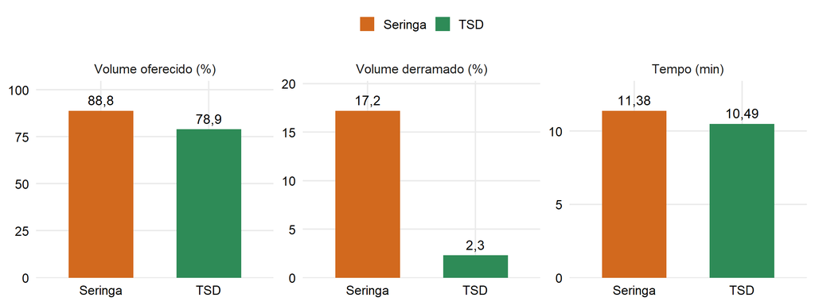

## AIG e PIG: comparação de subgrupos

| Variável | TSD AIG | TSD PIG | TSD p | Seringa AIG | Seringa PIG | Seringa p |
| --- | --- | --- | --- | --- | --- | --- |
| Volume oferecido (%) | 69,6 ± 22,0 | 92,8 ± 13,0 | 0,003 | 87,0 ± 14,4 | 91,5 ± 11,5 | 0,383 |
| Volume oferecido em 5 min (%) | 35,0 ± 10,5 | 41,5 ± 11,4 | 0,122 | 38,6 ± 8,6 | 40,3 ± 9,5 | 0,608 |
| Volume derramado (%) | 2,3 ± 4,1 | 2,4 ± 5,8 | 0,965 | 16,6 ± 7,6 | 17,9 ± 7,1 | 0,634 |
| Relacao volume/tempo (mL/min) | 3,04 ± 0,97 | 3,42 ± 1,01 | 0,316 | 3,34 ± 0,68 | 3,27 ± 0,90 | 0,827 |
| Tempo (min) | 9,90 ± 3,14 | 11,38 ± 3,13 | 0,218 | 11,27 ± 2,91 | 11,56 ± 2,49 | 0,781 |

Valores: média ± desvio-padrão. AIG = adequado para a idade gestacional, PIG = pequeno para a idade gestacional.

Na TSD, o volume oferecido foi maior no grupo **PIG: 92,8%**, contra **69,6% no AIG** (p = 0,003).

## Sinais vitais: tabela de médias

| Parâmetro | TSD Antes | TSD Durante | TSD Depois | TSD ANOVA | Seringa Antes | Seringa Durante | Seringa Depois | Seringa ANOVA |
| --- | --- | --- | --- | --- | --- | --- | --- | --- |
| Saturação de oxigênio (%) | 95,87 | 95,75 | 95,67 | Sem diferença* | 93,23 | 94,37 | 95,90 | 0,047 |
| Frequência cardíaca (bpm) | 134,2 | 149,17 | 145,50 | < 0,001 | 133,6 | 148,07 | 144,73 | < 0,001 |

*Artigo relata ausência de diferença, mas não publica o valor exato de p.

Valores médios de saturação de oxigênio e frequência cardíaca em cada momento da oferta, para os dois métodos.

## Sinais vitais ao longo da alimentação

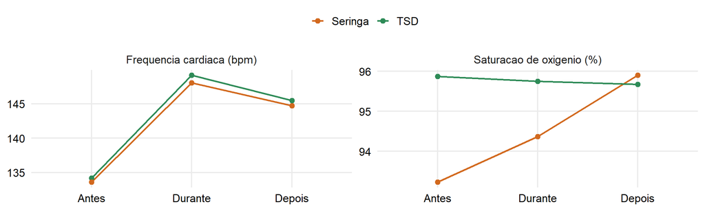

**Linha verde: TSD. Linha laranja: seringa.** Frequência cardíaca: sobe entre antes/durante e antes/depois, nos dois métodos (p < 0,001). Saturação: só varia com a seringa, entre antes e depois — com p = 0,05, bem na linha que separa “significativo” de “não significativo”.

# Conclusão

## Limites da interpretação

- **Ordem fixa:** todos fizeram seringa antes da TSD — efeito de adaptação se mistura ao efeito do método.
- **Um dia só por bebê:** não diz nada sobre dias seguintes, peso ou aleitamento a médio prazo.
- **Amostra local, seringa única:** 30 bebês de um hospital, um só calibre — pode não generalizar.
- **Normalidade não verificada:** artigo afirma, mas não mostra teste, gráfico ou critério.
- **5 testes t sem correção:** aumenta a chance de achar “significativo” por acaso.